# Final Static Portfolio

Ian Lyons

2/17/2019

# Sourcing

- Source for tax expenditures on the Treasury Department Website: https://home.treasury.gov/policy-issues/tax-policy/tax-expenditures
- Source for federal outlays on the Office of Management and Budget website: https://www.whitehouse.gov/omb/supplemental-materials/

```r
tax_long <- gather(base_df, fiscal_year, expenditure, '2018':'2028', factor_key=TRUE)
tax_long$FY2019_to_2028 <- NULL
```

```r
custom_pal <- c("#3FC1C9", "#B9F3FF", "#8A4DCC", "#4DCC74", "#EEB9FF", "#CC534D", "#CC7776", "#FFF07A")

# These colors are from the brewer 'Dark2' palette
bea_palette <- c("Commerce and housing" = "#3FC1C9", "Income security" = "#ED713A", "Health" = "#7570B3", "Education, training, employment, and social services" = "#E7298A", "International affairs" = "#66A61E","Addendum: Aid to State and local governments:" = "#E6AB02", "General purpose fiscal assistance" = "#A6761D")

iltheme <- theme(plot.title = element_text(color="black", size=22, face="bold", family="Verdana", hjust=0),
                text = element_text(family="Courier New", size=14),
                plot.subtitle = element_text(color="#4c4e4d", size=16, hjust=0, family = "Verdana"),
                axis.title.x = element_text(color="black", size=20, family="Verdana"),
                axis.title.y = element_text(color="black", size=20, family="Verdana"),
                plot.caption = element_text(color="black", size=14, face="italic"),
                axis.text.x = element_text(size=14),
                axis.text.y = element_text(size=14),
                plot.background=element_rect(fill="#F0F0F0"),
                panel.background =element_rect(fill="#F0F0F0"),
                panel.grid.minor.y = element_blank(),
                axis.ticks = element_blank(),
                axis.line = element_line(size=1, color = "Black"),
                legend.text = element_text(size=16))
```

# Largest Tax Expenditures By Category

Tax expenditures are what we usually refer to as tax loopholes or tax breaks. The US Department of Treasury classifies these tax provisions as tax “expenditures” in recognition of the fact that they are “often viewed as alternatives to other policy instruments, such as spending or regulatory programs” ([Treasury](https://home.treasury.gov/policy-issues/tax-policy/tax-expenditures)).

In the United States, many policies act though the tax code rather than through fiscal policy. For instance, other developed nations generally provide health care and/or health insurance for all of their citizens directly though national insurance/medical programs. However, in the United States most people receive insurance through their employer, perhaps not even realizing the generous tax treatment they and their employer are receiving.

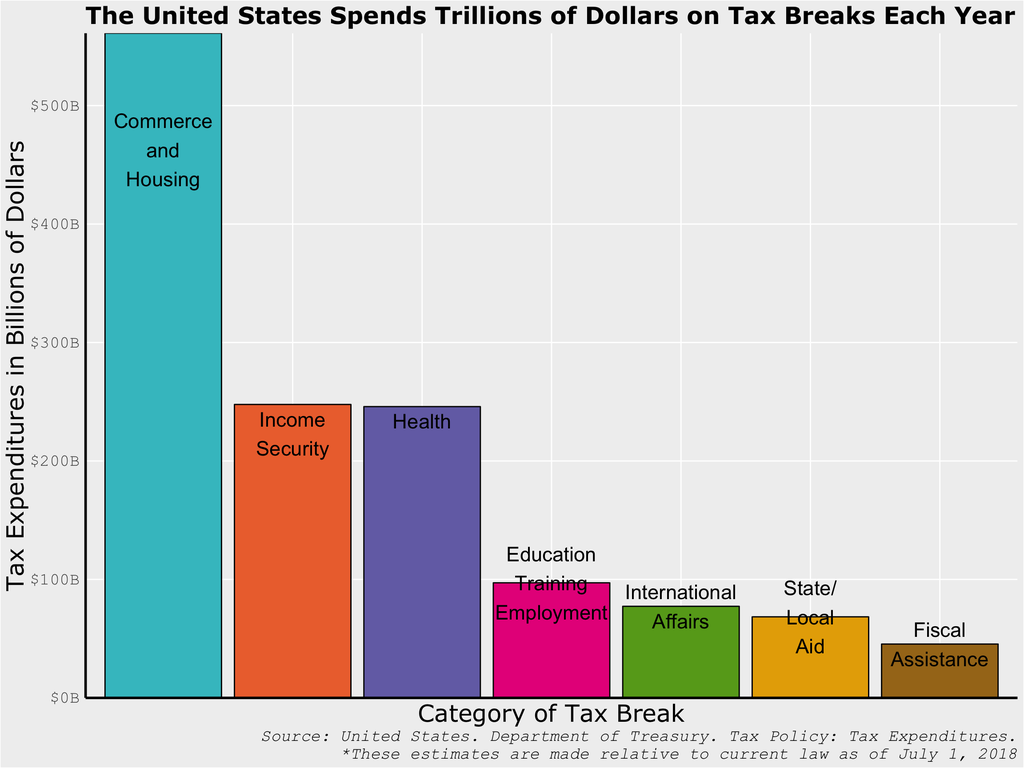

```r
time_series <- tax_long %>% select(fiscal_year, Category, expenditure) %>% filter(fiscal_year %in% c(2018)) %>%
  group_by(fiscal_year, Category) %>% tally(expenditure)

time_series <- mutate(.data = time_series, amount_billions = n/1000)
time_series$n <- NULL
time_series <- arrange(time_series, -amount_billions)
top7 <- top_n(time_series, 7)


bar_to_plot <- ggplot(data=top7, aes(x=reorder(Category, -amount_billions), y=amount_billions, fill=Category)) +
  geom_col(position = "dodge", color="black")

labelling <-geom_text(aes(label= c("\n\n\n\n\n\n\n\nCommerce\nand\nHousing",
                         "\n\nIncome\nSecurity",
                         "\nHealth",
                         "Education\nTraining\nEmployment",
                         "International\nAffairs",
                         "State/\nLocal\nAid",
                         "Fiscal\nAssistance"),
                         color="black",
                         vjust=0.5),
            position = position_identity(),
            color="black", size = 6)

plot1 <- bar_to_plot +
    scale_y_continuous(expand = c(0,0),
                       name = "Tax Expenditures in Billions of Dollars",
                       labels = scales::dollar_format(accuracy = 1, suffix = 'B')) +
    scale_x_discrete() +
    labs(title = "The United States Spends Trillions of Dollars on Tax Breaks Each Year",
         caption = "Source: United States. Department of Treasury. Tax Policy: Tax Expenditures.\n*These estimates are made relative to current law as of July 1, 2018",
         x = "Category of Tax Break") +
  labelling +
  iltheme +
  theme(legend.position="none",
        axis.text.x = element_blank(),
        plot.title = element_text(color="black", size=20, face="bold", family="Verdana", hjust=0)) +
  scale_fill_manual(values=bea_palette)

ggsave(filename = 'visuals/BiggestCategoryOfBreaks.pdf', width = 11, height = 8.5)
last_plot()
```

# The largest individual tax expenditures in 2018

The deduction for premiums for employer-sponsored health care plans alone costs over $205 billion a year, according to the Department of Treasury. This deduction has also been blamed for pushing up health care spending in general by encouraging more generous plans with lower cost-sharing and [less managed care.](https://www.taxpolicycenter.org/briefing-book/how-does-tax-exclusion-employer-sponsored-health-insurance-work)

```r
taxex <- filter(tax_long, fiscal_year == 2018)
top10 <- top_n(taxex, 10)
top10 <- arrange(top10, -expenditure)

details <- c("Employer health care exclusion", "Capital gains tax rate", "Treatment of net imputed rental income", "Defined contribution employer plans", "Employer pension plans", "Accelerated depreciation", "Reduced taxes on income of foreign corporations", "Step-up basis of capital gains", "Charitable contributions", "Capital gains exclusion- home sales")

descr <- labs(title = "The Employer Health Care Deduction Dwarfs Other Tax Breaks",
              subtitle = "Investor & Housing Tax Breaks Are Half of the Most Expensive Tax Breaks",
              caption = "Source: United States. Department of Treasury. Tax Policy: Tax Expenditures. \n
              * These estimates are made relative to current law as of July 1, 2018",
              x = "Description of Tax Break")

expend_plot <- ggplot(data=top10,
                      aes(x=reorder(details, expenditure),
                          y=expenditure,
                          color=Category,
                          fill=Category)) +
  geom_col(color="black") +
  coord_flip() +
  scale_y_continuous(expand = c(0.005, 0),
                     name = "Size of Tax Break in Dollars",
                     labels = scales::dollar_format(scale = .001,
                                                    accuracy = 1,
                                                    suffix = 'B')
                     ) +
  scale_x_discrete(labels = scales::wrap_format(18)) +
  scale_fill_manual(name="Treasury-Assigned Category",
                    values=bea_palette
                    ) +
  descr +
  iltheme +
  theme(legend.position =c(.8, .2),
        legend.text = element_text(size = 12),
        legend.title = element_text(size = 14),
        axis.text.x = element_text(size=14),
        axis.text.y = element_text(size=12),
        plot.title = element_text(color="black", size=20, face="bold", family="Verdana", hjust=0)
        )

ggsave(filename = 'visuals/BiggestIndividualBreaks.pdf', width = 13, height = 11)
#last_plot()
```

```r
# Prep For Plots 2 & 3: Group by agency name and sum expenditures within the same agency and year.
# * Create a long-form version of the outlays dataset to use in a time-series plot. That is, create one row for each line item (agency name, bureau name, account name, etc.) and fiscal year.
budget_longform <- gather(budg_2019, fiscal_year, expenditure, '1962':'2023', factor_key=TRUE)

## Keep only descriptive column names rather than codes.
keep_cols <- c('Agency Name', 'Bureau Name', 'Account Name', 'Treasury Agency Code', 'Subfunction Title', 'BEA Category', 'Grant/non-grant split' , 'On- or Off- Budget', 'fiscal_year', 'expenditure')

budget_longform <- budget_longform[keep_cols]
```

```r
# Take the reshaped longform budget data and group by fiscal year and agency name.

outlays <- budget_longform %>% select(fiscal_year, `Agency Name`, expenditure) %>%
            group_by(fiscal_year, `Agency Name`) %>%
            tally(expenditure)

## Give the expenditures column a descriptive name
outlays <- mutate(.data = outlays, dollars_thousands = n)
outlays$n <- NULL

## Rename `Agency Name` in snake case.
colnames(outlays)[2] <- 'agency_name'
```

# Annual Outlays 1998-2019 of Some of the Largest Agencies & Departments

The September 11th 2001 terrorist attacks and the subsequent invasions of Afghanistan and Iraq saw Department of Defense Expenditures soar, until hostilities started to wind down in 2010 or so. The Department of Homeland Security, founded in 2002, has consistently received $50-$100 billion per year. The increase in 2018 funding for both departments is a reflection of the Trump administration’s priorities.

```r
facet_data <- outlays %>%
  filter(fiscal_year  %in% c(1998:2019)) %>%
  filter(agency_name %in% c("Department of Agriculture",
  "Department of Defense--Military Programs",
  "Department of Education",
  "Department of Homeland Security",
  "Department of Labor",
  "Department of the Treasury",
  "Department of Veterans Affairs",
  "Department of State",
  "Department of Justice"))

facet_data <- mutate(facet_data, agency_name = ifelse(agency_name == "Department of Defense--Military Programs", "Department of Defense", agency_name))

facet_plot <- facet_data %>% ggplot(aes(x = fiscal_year, y = dollars_thousands)) +
    annotate(geom = 'rect',
             ymin = -Inf,
             ymax = Inf,
             xmin =10.917,
             xmax = 12.5,
             fill = 'red',
             alpha = 0.2) +
    annotate(geom = 'rect',
             ymin = -Inf,
             ymax = Inf,
             xmin = 3.25,
             xmax = 3.83,
             fill = 'red',
             alpha = 0.2) +

  annotate(geom = "segment", x = 3.75, xend = 3.75, y = 0, yend=Inf,
             fill = 'black',
             alpha = 0.7, linetype=3) +
  annotate(geom = "text", x = 3.75, y = Inf, hjust=1, vjust=1.0,
             fill = 'black',
             alpha = 0.7, label="9/11\nTerrorist\nAttacks", size=3) +

  annotate(geom = "segment", x = 5.22, xend = 5.22, y = 0, yend=Inf,
             fill = 'black',
             alpha = 0.7, linetype=3) +
  annotate(geom = "text", x = 5.22, y = Inf, hjust=-.1, vjust=1.0,
             fill = 'black',
             alpha = 0.7, label="Iraq War", size=3) +

  annotate(geom = "segment", x = 20.055, xend = 20.055, y = 0, yend=Inf,
             fill = 'black',
             alpha = 0.7, linetype=2) +
  annotate(geom = "text", x = 20.055, y = Inf, hjust=-.1, vjust=1.0,
             fill = 'black',
             alpha = 0.7, label="Trump\nInaugurated", size=3) +

  annotate(geom = "segment", x = 12.055, xend = 12.055, y = 0, yend=Inf,
             fill = 'black',
             alpha = 0.7, linetype=2) +
  annotate(geom = "text", x = 12.055, y = Inf, hjust=-.1, vjust=1.0,
             fill = 'black',
             alpha = 0.7, label="Obama\nInaugurated", size=3) +
  geom_col() +
  facet_wrap(~agency_name) +
  scale_y_continuous(name = "Outlays",
                     labels = scales::dollar_format(scale=.000001,
                                                    accuracy = 1,
                                                    suffix = 'B')) +
  scale_x_discrete( breaks=(seq(1998,2019,2)),
                   labels = (seq(1998,2019,2))
                   ) +
  labs(title = "Defense Generously Funded While Other Departments Languish",
       subtitle = "Red shading indicates recessions",
       caption="Source: United States. Office of Management and Budget. Public Budget Database.",
       x = "Fiscal Year",
       y = "Outlays") + iltheme +
  theme(axis.text.x = element_text(angle = 90),
        strip.text = element_text(face = "bold",
                                  size = rel(1.0)),
        axis.text = element_text(size=2),
        legend.position="none",
        plot.title = element_text(color="black", size=20, face="bold", family="Verdana", hjust=0, vjust=1))

ggsave(filename = 'visuals/Outlays_Since1995_FacetWrap.pdf', width = 11, height = 8.5)
#last_plot()
```

# Breakdown of Federal Spending: Top 8 Agencies/Departments by Outlays

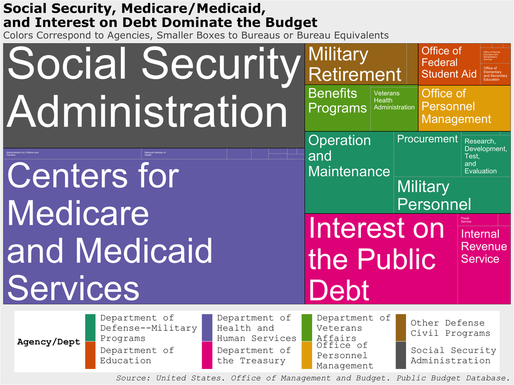

```r
top8agencies <- c("Department of Health and Human Services", "Social Security Administration", "Department of the Treasury", "Department of Defense--Military Programs", "Department of Veterans Affairs", "Other Defense Civil Programs", "Office of Personnel Management", "Department of Education")
HHSonly <- budget_longform %>% filter(fiscal_year %in% c(2017) & `Agency Name` %in% top8agencies)
HHS <-  HHSonly %>% select(fiscal_year, `Agency Name`, `Bureau Name`, expenditure) %>% filter(expenditure > 1000000) %>% group_by(fiscal_year, `Agency Name`, `Bureau Name`) %>% summarise(exp=sum(expenditure))

projected <-  HHS %>% ggplot(aes(area=exp,
                                 fill=`Agency Name`,
                                 label = `Bureau Name`,
                                 subgroup=`Agency Name`)) +
  geom_treemap()  +
  iltheme +
  geom_treemap_text(colour="white", place = "topleft",
                    grow = TRUE,
                    reflow = TRUE,
                    min.size = 3,
                    padding.x = grid::unit(unit="mm", 2),
                    padding.y = grid::unit(unit="mm", 2)) +
  geom_treemap_subgroup_border(colour = "black",
                               size = 1) +
  theme(legend.position="bottom", legend.title = element_text(face = "bold", size=16)) +
  scale_fill_brewer(palette = "Dark2",
                    labels = scales::wrap_format(16),
                    name="Agency/Dept") +
  scale_size_area() +
  labs(title = "Social Security, Medicare/Medicaid,\nand Interest on Debt Dominate the Budget",
       subtitle = "Colors Correspond to Agencies, Smaller Boxes to Bureaus or Bureau Equivalents",
       caption = "Source: United States. Office of Management and Budget. Public Budget Database.")

ggsave(filename = 'visuals/TreemapTop8.pdf', width = 11, height = 8.5)

last_plot()
```

# How is departmental and agency spending categorized?

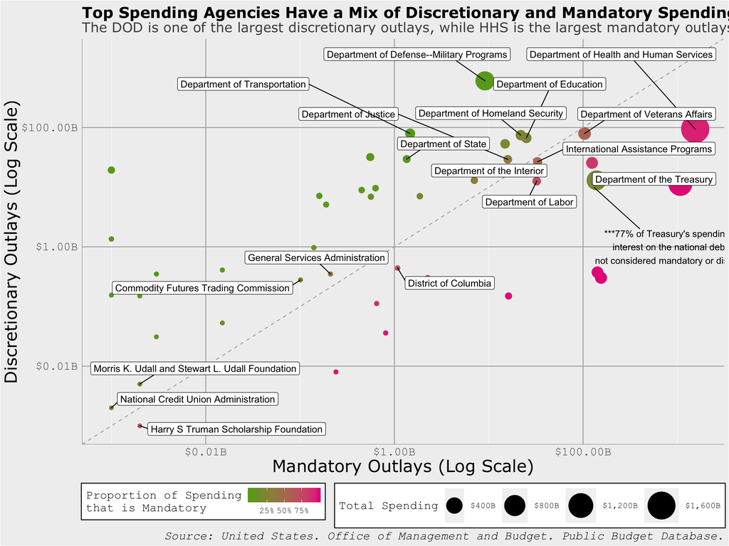

# Spending Over Time

The share of federal spending classified as mandatory has grown as a percentage of total spending since the 1960s.

Mandatory spending is spending controlled by laws other than annual appropriations acts. This spending has been mandated by Congress in the past and does does have to be reappropriated each year. Most mandatory programs are fall under health care (e.g. Medicare, Medicaid), social security, and other income support programs. Spending on mandatory programs is determined by the number of eligible recipients.

Discretionary spending must be appropriated each year by the House and Senate. The largest portion of discretionary spending is funding for the Department of Defense and other defense-related programs. Non-defense discretionary spending, just under half of total discretionary spending in 2018, accounts for all federal spending on diplomacy, education, transportation, research, law enforcement, and paying for the operations of the federal government.

# Revenues Over Time

The federal government can borrow money, or collect taxes/revenues to finance its activities. Revenues can be collected from individuals or businesses, through fees, sales taxes, profit taxes, payroll taxes, or through tariffs- taxes on foreign goods.

Since 1962, the proportion of revenue collected through payroll taxes and individual income taxes has increased substantially. The proportion of revenues collected through the corporate income tax and excise taxes (sales taxes, such as the federal gasoline tax) has fallen. The share of revenue from payroll taxes has increased from about 20% of revenues in 1962, to about 35% in 2018. Individual income taxes have gone from a little over 40% of revenues to almost 50% of all federal revenue.

# Budget Deficit And Surplus

For the vast majority of the post-World War 2 era, the United States government has run a budget deficit. A budget surplus was achieved for only a handful of years, during the Truman administration and much later during the Clinton administration.

You can see the effects of wars and recessions on the budget surplus or deficit. During the late-2000’s Great Recession, for example, the deficit ballooned to over 10% of GDP thanks to falling revenue and increased spending on automatic stabalizers, like unemployment insurance and SNAP benefits.

The budgetary policies of the Clinton administration, which was forced to work alongside an austere Republican congress after 1994, achieved a deficit reduciton that achieved a surplus for the first time in nearly 50 years.

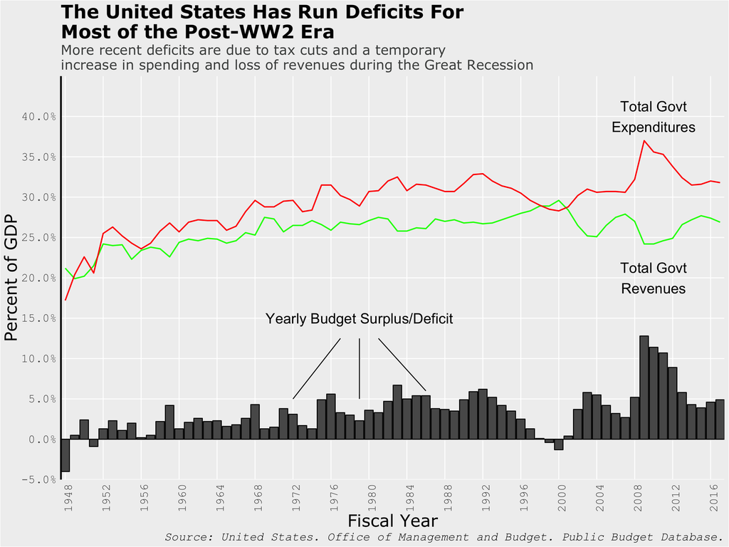

```r
percent_gdp <- read_csv("raw_data/PercentOfGDP.csv")


surp_def <- ggplot(data=percent_gdp, aes(x = `Fiscal Year`, y = `Total Revenues`)) +
  geom_line(color = "green",
            size = 0.75) +
  geom_line(aes(x=`Fiscal Year`,
                y = `Total Expenditures`),
            size = 0.75,
            color = "red")+
  geom_col(aes(x=`Fiscal Year`,
                y = `Total Expenditures`-`Total Revenues`),
            color="black") +
  labs(title = "The United States Has Run Deficits For\nMost of the Post-WW2 Era",
       subtitle = "More recent deficits are due to tax cuts and a temporary\nincrease in spending and loss of revenues during the Great Recession",
       caption="Source: United States. Office of Management and Budget. Public Budget Database.",
       x = "Fiscal Year",
       y = "Percent of GDP") +
  iltheme +
  geom_abline(intercept = 0,
              slope = 0,
              color="black") +
  annotate(geom = "text", x = 2010, y = .40,
             fill = 'black',
             alpha = 1,
             label="Total Govt\nExpenditures",
             size = 6) +
  annotate(geom = "text", x = 2010, y = .20,
             fill = 'black',
             alpha = 1,
             label="Total Govt\nRevenues",
             size = 6) +
  annotate(geom = "text", x = 1979, y = .15,
             fill = 'black',
             alpha = 1,
             label="Yearly Budget Surplus/Deficit",
             size = 6) +
  annotate(geom = "segment",
           x = 1979, y = .125 ,
           xend = 1979, yend = .05) +
  annotate(geom = "segment",
           x = 1977, y = .125 ,
           xend = 1972, yend = .05) +
  annotate(geom = "segment",
           x = 1981, y = .125 ,
           xend = 1986, yend = .06) +
  scale_y_continuous(limits = c(-.05,0.45),
                     labels = scales::percent_format(),
                     breaks = seq(-0.05,0.4,by=.05),
                     expand = c(0,0),
                     name="Percent of GDP") +
  scale_x_continuous(breaks = (seq(1948,2017,4)),
                   labels = (seq(1948,2017,4)),
                   expand = c(0,0)) +
  theme(axis.line.x.bottom = element_blank(),
        panel.grid.minor = element_blank(),
        axis.text.x = element_text(angle = 90))

surp_def
```

# Federal Aid to State & Local Governments

In Fiscal Year 2018, the federal government was projected to grant about $728 billion to state and local governments. According to the Congressional Research Service, federal grants make up one-third of state spending, and more than half of state spending on health care and other public assistance programs. Since the expansion of Medicaid included in the Affordable Care Act (ACA), the amount of federal grant money flowing to health care has only increased.

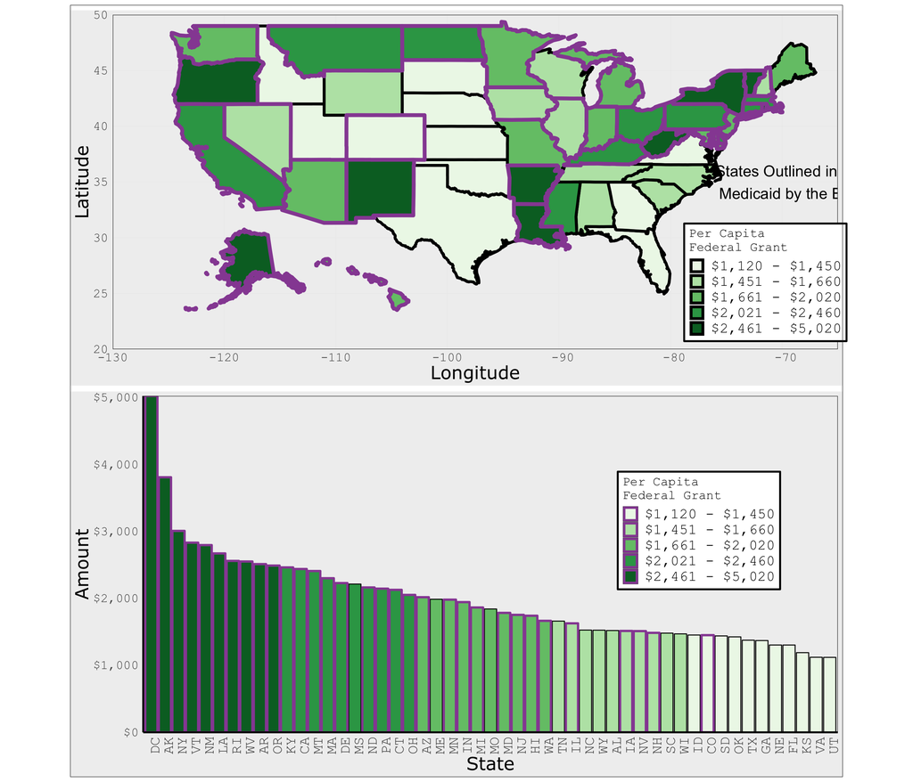

```r
breaks <- quantile(x = joined$`2018 grant per capita`,seq(0,1,.20))
bins <- cut(joined$`2018 grant per capita`, unique(breaks), include.lowest=TRUE)
joined$bins <- bins

# Create a list of states that expanded Medicaid by the beginning of 2018, since grants seem to be strongly related to Medicaid expansion.
expanded <- c("AK", "HI", "NM", "AZ", "CA", "CO", "NV", "OR", "WA", "MT", "ND", "MN", "AR", "LA", "IA", "MI", "IL", "IN", "OH", "KY", "WV", "DC", "MD", "DE", "CT", "NJ", "PA", "CT", "RI", "MA", "NH", "VT", "NY")
bin_labels <- c("$1,120 - $1,450", "$1,451 - $1,660", "$1,661 - $2,020", "$2,021 - $2,460", "$2,461 - $5,020")

mapped_pc <- ggplot(data=joined) +
  geom_sf(aes(fill = (bins)),color="black", size=1.5) +
  geom_sf(data = filter(joined, STUSPS %in% expanded),
          aes(fill = bins),
          color="#974ea2", size=2, show.legend = FALSE) +
  annotate(geom = "text",
           x = -65,
           y = 35,
           label = "States Outlined in Purple Expanded\nMedicaid by the Beginning of 2018",
           size = 6) +
  coord_sf(xlim = c(-130, -65),
           ylim = c(20, 50),
           expand = FALSE) +
  scale_fill_brewer(name="Per Capita\nFederal Grant",
                    palette = "Greens",
                    type = "div",
                    labels = bin_labels) +
  iltheme +
  theme(axis.line = element_blank(),
        legend.background = element_rect(size=1,
                                         linetype="solid",
                                         colour ="black"),
        panel.background = element_rect(fill = NA, size = .2),
        legend.position=c(.9, .2)) + xlab("Longitude") + ylab("Latitude")

column_pc <- ggplot(data = joined, aes(x = reorder(STUSPS, -`2018 grant per capita`), y = `2018 grant per capita`)) +
  geom_col(aes(fill = bins), color="black") +
  geom_col(data = filter(joined, STUSPS %in% expanded),
          aes(fill = bins, labels=STUSPS),
          color="#974ea2", size=1.2) +
  iltheme +
  scale_fill_brewer(name="Per Capita\nFederal Grant",
                    palette = "Greens",
                    type = "div",
                    labels = bin_labels) +
  scale_y_continuous(name="Amount",
                     labels = scales::dollar_format(),
                     expand = c(0,0)) +
  scale_x_discrete(name="State") +
  theme(axis.text.x.bottom = element_text(angle = 90),
        panel.grid = element_blank(),
        axis.text.x = element_text(size=16),
        legend.background = element_rect(size=1,
                                         linetype="solid",
                                         colour ="black"),
        panel.background = element_rect(fill = NA, size = 1),
        panel.ontop = TRUE,
        legend.position=c(.8, .6))

multiplot <- ggplot() + coord_equal(xlim = c(0, 4),
                       ylim = c(0, 4), expand = FALSE) +
  annotation_custom(ggplotGrob(mapped_pc), xmin = 0, xmax = 4,
                    ymin = 2, ymax = 4) +
  annotation_custom(ggplotGrob(column_pc), xmin = 0, xmax = 4,
                    ymin = 0, ymax = 2)

ggsave("visuals/PerCapMap.pdf", plot = mapped_pc)
ggsave("visuals/MulttiPerCapMap.pdf", plot = multiplot)
ggsave("visuals/ColumnPerCapMap.pdf", plot = column_pc, width = 11, heigh = 8.5)


multiplot
```